# Final Exam Practice Questions - Part 1

**I know it’s tempting, but don’t click the solution tab until you are certain you have solved the question, or are utterly stumped by it.**

# Question 1.

### Most of the questions below use the dataset **dataSet1.csv**. In most cases, answering the questions will be easiest if the data is converted to a “tidy” format. Convert **dataSet1.csv** to a “tidy” format and print the first 10 rows. Rename the two columns to be “Group” and “Score”.

**Click for Solution**

```r
# Note that there are many ways to do this
library(tidyverse)
data <- read_csv("dataSet1.csv")

# Reshaping the data
data_tidy <- pivot_longer(
  data,
  cols = 1:length(data),
  names_to = "Group",
  values_to = "Score"
)

data_tidy[1:10, ]
```

```
## # A tibble: 10 × 2
##    Group   Score
##    <chr>   <dbl>
##  1 A      1.294
##  2 B      7.540
##  3 C     -1.534
##  4 D     -1.547
##  5 E     -0.2899
##  6 F     -4.143
##  7 G      2.097
##  8 H     -2.359
##  9 A      2.109
## 10 B      3.477
```

# Question 2.

### For each column in **dataSet1.csv** calculate the mean, variance, and standard deviation for both populations and samples. Don’t use the `mean()`, `var()`, or `sd()` functions.

- Hint: there are two ways to go about this: The long laborious way and the shorter convenient way. Which will you choose?

**Click for Solution**

```r
# Get Stats
results <- data_tidy |>
  group_by(Group) |>
  summarise(
    n = length(Score),
    m = sum(Score) / n,
    pop_var = sum((Score - m)^2) / (n),
    samp_var = sum((Score - m)^2) / (n - 1),
    pop_sd = sqrt(sum((Score - m)^2) / (n)),
    samp_sd = sqrt(sum((Score - m)^2) / (n - 1))
  )

results
```

```
## # A tibble: 8 × 7
##   Group     n        m pop_var samp_var pop_sd samp_sd
##   <chr> <int>    <dbl>   <dbl>    <dbl>  <dbl>   <dbl>
## 1 A       200  0.8606   3.769    3.788  1.941   1.946
## 2 B       200  2.889    9.311    9.358  3.051   3.059
## 3 C       200 -1.007    1.035    1.040  1.017   1.020
## 4 D       200 -0.9935   1.004    1.009  1.002   1.005
## 5 E       200 -0.9677   0.8176   0.8217 0.9042  0.9065
## 6 F       200 -0.06199  4.348    4.370  2.085   2.090
## 7 G       200  0.8266   4.691    4.715  2.166   2.171
## 8 H       200 -1.038    0.9384   0.9431 0.9687  0.9711
```

# Question 3.

### Plot histograms of each column in **dataSet1.csv**. (Hint this is really easy if you’ve “tidied up” your data).

**Click for Solution**

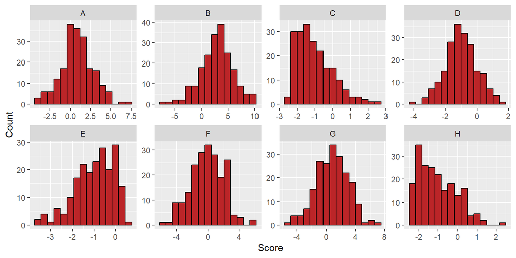

```r
ggplot(data_tidy, aes(x = Score)) +
  geom_histogram(bins = 15, fill = "#BB2528", colour = "black") +
  facet_wrap(~Group, scales = "free", nrow = 2) +
  xlab("Score") +
  ylab("Count")
```

- Note: The argument `scales = "free"` tells ggplot to allow the x and y axis scales to vary across the facets. Functionality like this is why ggplot is so useful. Imagine trying to create an equivalent plot in Microsoft Excel (*shudders*).

# Question 4.

### Plot boxplots of each column in **dataSet1.csv**.

**Click for Solution**

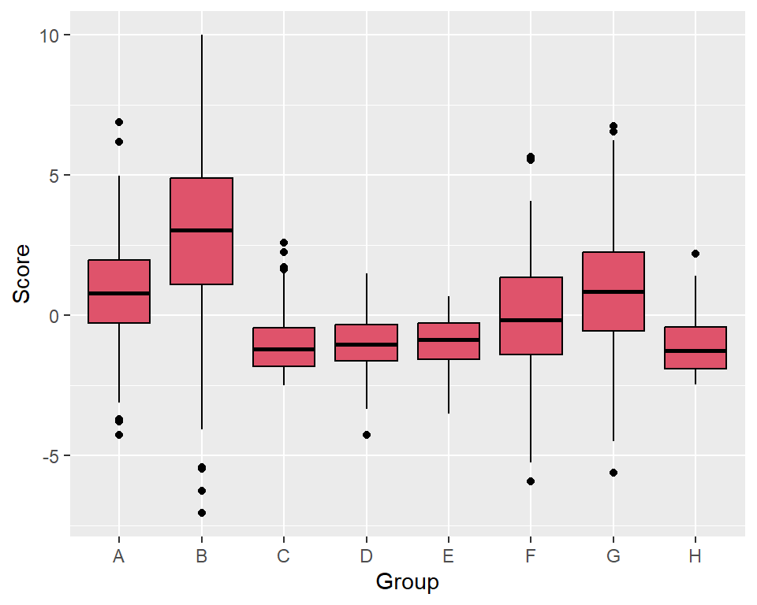

```r
ggplot(data_tidy, aes(x = Group, y = Score)) +
  geom_boxplot(fill = "#DF536B", colour = "#000000") +
  xlab("Group") +
  ylab("Score")
```

# Question 5.

### Plot Q-Q plots of each column in **dataSet1.csv**. Which ones are not normally distributed and how are they skewed?

**Click for Solution**

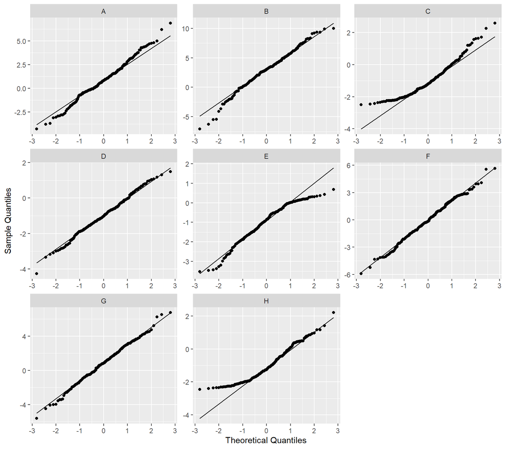

```
## C: Positively Skewed
```

```
## E: Negatively Skewed
```

```
## H: Positively Skewed
```

```r
ggplot(data_tidy, aes(sample = Score)) +
  stat_qq(colour = "black") +
  stat_qq_line(colour = "black") +
  facet_wrap(~Group, scales = "free") +
  xlab("Theoretical Quantiles") +
  ylab("Sample Quantiles")
```

# Question 6.

### Transform the skewed columns in **dataSet1.csv** to make them as normal looking as possible. Plot them as a **density** plot. Report the value of Tukey’s lambda you used for each.

- *Note: if there are negative values in the data, you should probably figure out a simple way to remove them, otherwise you might have difficulty transforming your data.*

#### **Column C’s Data**

**Click for Solution**

```r
library(rcompanion)

# Get smallest value
min(data$C)
```

```
## [1] -2.505994
```

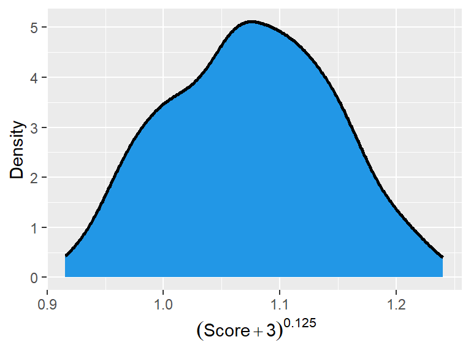

```r
# Since the smallest value is -2.5 I will add 3 to all the values when I
# calculate lambda and plot the data.  This is to prevent negatives and zeros.
lambdaC <- transformTukey((data$C + 3),
  plotit = FALSE,
  returnLambda = TRUE,
  quiet = TRUE
)

# Plot
ggplot(data, aes(x = (C + 3)^lambdaC)) +
  geom_density(fill = "#2297E6", linewidth = 1, colour = "black") +
  xlab(bquote(~ (Score + 3)^.(lambdaC))) +
  ylab("Density")
```

#### **Column E’s Data**

**Click for Solution**

```r
# E
# Get smallest value
min(data$E)
```

```
## [1] -3.515044
```

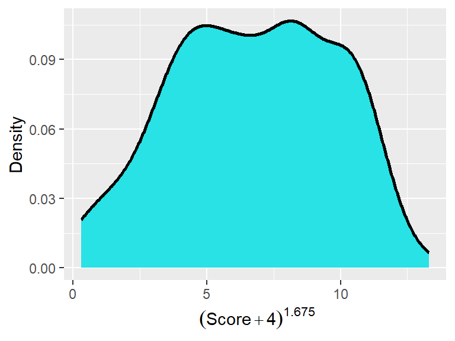

```r
# Store Lambda
lambdaE <- transformTukey((data$E + 4),
  plotit = FALSE,
  returnLambda = TRUE,
  quiet = TRUE
)

# Plot
ggplot(data, aes(x = (E + 4)^lambdaE)) +
  geom_density(fill = "#28E2E5", linewidth = 1, colour = "black") +
  xlab(bquote(~ (Score + 4)^.(lambdaE))) +
  ylab("Density")
```

#### **Column H’s Data**

**Click for Solution**

```r
# H
# Get smallest value
min(data$H)
```

```
## [1] -2.461425
```

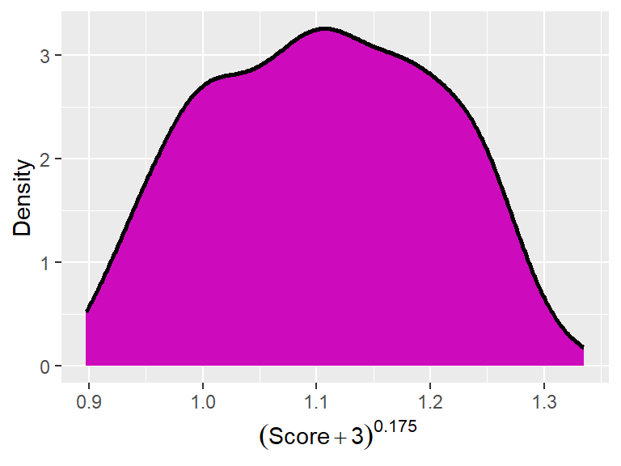

```
## C: lambda =  0.125
```

```
## E: lambda =  1.675
```

```
## H: lambda =  0.175
```

```r
# Store Lambda
lambdaH <- transformTukey((data$H + 3),
  plotit = FALSE,
  returnLambda = TRUE,
  quiet = TRUE
)

# Plot
ggplot(data, aes(x = (H + 3)^lambdaH)) +
  geom_density(fill = "#CD0BBC", linewidth = 1, colour = "black") +
  xlab(bquote(~ (Score + 3)^.(lambdaH))) +
  ylab("Density")
```

# Question 7.

### For each column, A - D, in **dataSet1.csv**, test the hypotheses that $H_0: \mu_0 = -0.833$. For the remaining columns, E - H, test $H_0: \mu_0 > -0.833$.

- **Set $\alpha = 0.01$.**
- Test using both a classic t-test and a trimmed t-test with 20% trimming.
- You are **not** allowed to use the function `t.test()`.
- Report test-statistic, degrees of freedom, p-value, and confidence intervals.
- Again, there is a fast way to do this, and a slow laborious way. Which will you choose?

#### **Columns A - D Classic One-Sample T-Tests: $H_0: \mu_0 = -0.833$**

**Click for Solution**

```r
# Separate Columns A-D (see note at bottom)
data_AD <- filter(data_tidy, Group %in% c("A", "B", "C", "D"))

# Use summarise() to run your t-tests and save yourself hours of typing
classic_AD <- data_AD |>
  group_by(Group) |>
  summarise(

    # Basic Stats
    mu = -0.833,
    alpha = 0.01,
    n = length(Score),
    m = mean(Score),
    se = sd(Score) / sqrt(n),

    # Degrees of Freedom
    df = n - 1,

    # Test Statistic and P-value
    t_stat = (m - mu) / se,
    p = pt(abs(t_stat), df = df, lower.tail = FALSE) * 2,

    # Confidence Intervals
    t_crit = abs(qt(alpha / 2, df = df)),
    moe = t_crit * se,
    CI = paste(
      "[",
      round(m - moe, 3), ", ",
      round(m + moe, 3),
      "]",
      sep = ""
    )
  )

classic_AD |>
  select(Group, t_stat, df, p, CI)
```

```
## # A tibble: 4 × 5
##   Group t_stat    df         p CI
##   <chr>  <dbl> <dbl>     <dbl> <chr>
## 1 A     12.31    199 2.993e-26 [0.503, 1.219]
## 2 B     17.21    199 2.971e-41 [2.327, 3.452]
## 3 C     -2.418   199 1.650e- 2 [-1.195, -0.82]
## 4 D     -2.259   199 2.499e- 2 [-1.178, -0.809]
```

- Note: `%in%` just identifies if a value is contained in a vector. In this case it returns `TRUE` when the value in the group column contains A, B, C, or D, and returns `FALSE` for anything else.

#### **Columns A - D Trimmed One-Sample T-Tests: $H_0: \mu_0 = -0.833$**

**Click for Solution**

```r
library(WRS2)

trim_AD <- data_AD |>
  group_by(Group) |>
  summarise(

    # Basic Stats
    alpha = 0.01,
    mu = -0.833,
    n = length(Score),

    # Trimmed mean and sd
    G = 0.20,
    m = mean(Score, tr = G),
    s = sqrt(winvar(Score, tr = G)),

    # Standard Error for Confidence Interval Calculation
    se = s / ((1 - 2 * G) * sqrt(n)),

    # Degrees of Freedom
    h = n - 2 * floor(G * n),
    df = h - 1,

    # Margin of Error for Confidence Interval
    t_crit = abs(qt(alpha / 2, df = df)),
    moe = t_crit * se,

    # Test statistic and P-value
    t_stat = ((1 - 2 * G) * (m - mu)) / (s / sqrt(n)),
    p = pt(abs(t_stat), df = df, lower.tail = FALSE) * 2,

    # Confidence Interval
    CI = paste(
      "[",
      round(m - moe, 3), ", ",
      round(m + moe, 3),
      "]",
      sep = ""
    )
  )

trim_AD |>
  select(Group, t_stat, df, p, CI)
```

```
## # A tibble: 4 × 5
##   Group t_stat    df         p CI
##   <chr>  <dbl> <dbl>     <dbl> <chr>
## 1 A     12.56    119 1.514e-23 [0.471, 1.158]
## 2 B     17.92    119 1.356e-35 [2.421, 3.534]
## 3 C     -4.107   119 7.393e- 5 [-1.363, -0.95]
## 4 D     -2.336   119 2.119e- 2 [-1.184, -0.813]
```

#### **Columns E - H Classic One-Sample T-Tests: $H_0: \mu_0 > -0.833$**

**Click for Solution**

```r
# Separate Columns E-H
data_EH <- filter(data_tidy, Group %in% c("E", "F", "G", "H"))

# Use summarise()() to run your t-tests and save yourself hours of typing
classic_EH <- data_EH |>
  group_by(Group) |>
  summarise(

    # Basic Stats
    mu = -0.833,
    alpha = 0.01,
    n = length(Score),
    m = mean(Score),
    se = sd(Score) / sqrt(n),

    # Degrees of Freedom
    df = n - 1,

    # Test Statistic and P-value
    t_stat = (m - mu) / se,
    p = pt(t_stat, df = df),

    # Confidence Intervals
    t_crit = abs(qt(alpha, df = df)),
    moe = t_crit * se,
    CI = paste("[",
      round(m - Inf, 3), ", ",
      round(m + moe, 3),
      "]",
      sep = ""
    )
  )


classic_EH |>
  select(Group, t_stat, df, p, CI)
```

```
## # A tibble: 4 × 5
##   Group t_stat    df        p CI
##   <chr>  <dbl> <dbl>    <dbl> <chr>
## 1 E     -2.101   199 0.01846  [-Inf, -0.817]
## 2 F      5.216   199 1.000    [-Inf, 0.285]
## 3 G     10.81    199 1        [-Inf, 1.187]
## 4 H     -2.987   199 0.001587 [-Inf, -0.877]
```

#### **Columns E - H Trimmed One-Sample T-Tests: $H_0: \mu_0 > -0.833$**

**Click for Solution**

```r
trimmed_EH <- data_EH |>
  group_by(Group) |>
  summarise(
    # Basic Stats
    alpha = 0.01,
    mu = -0.833,
    n = length(Score),

    # Trimmed mean and sd
    G = 0.20,
    m = mean(Score, tr = G),
    s = sqrt(winvar(Score, tr = G)),

    # Standard Error for Confidence Interval Calculation
    se = s / ((1 - 2 * G) * sqrt(n)),

    # Degrees of Freedom
    h = n - 2 * floor(G * n),
    df = h - 1,

    # Margin of Error for Confidence Interval
    t_crit = abs(qt(alpha, df = df)),
    moe = t_crit * se,

    # Test statistic and P-value
    t_stat = ((1 - 2 * G) * (m - mu)) / (s / sqrt(n)),
    p = pt(t_stat, df = df),

    # Confidence Interval
    CI = paste("[",
      round(m - Inf, 3), ", ",
      round(m + moe, 3), "]",
      sep = ""
    )
  )

trimmed_EH |>
  select(Group, t_stat, df, p, CI)
```

```
## # A tibble: 4 × 5
##   Group  t_stat    df          p CI
##   <chr>   <dbl> <dbl>      <dbl> <chr>
## 1 E     -0.6200   119 0.2682     [-Inf, -0.704]
## 2 F      4.897    119 1.000      [-Inf, 0.354]
## 3 G     10.27     119 1          [-Inf, 1.247]
## 4 H     -4.060    119 0.00004404 [-Inf, -0.974]
```

# Question 8.

**Click for Solution**

```r
# Column A
out_A <- abs(data$A - median(data$A)) / mad(data$A) > 2.24
data$A[out_A]
```

```
##  [1] -3.790120  6.887835  4.812911  4.983126 -3.041135 -3.103121 -4.275498
##  [8]  4.687346  6.187907  4.736228 -3.688665
```

```r
# Column B
out_B <- abs(data$B - median(data$B)) / mad(data$B) > 2.24
data$B[out_B]
```

```
## [1] -5.418952  9.358617 -3.628073 -4.071440  9.999879  9.861733 -7.047248
## [8] -6.268396 -5.475362
```

```r
# Column D
out_D <- abs(data$D - median(data$D)) / mad(data$D) > 2.24
data$D[out_D]
```

```
## [1]  1.483991  1.170677 -4.266616  1.076770 -3.180537  1.299997 -3.340685
```

```r
# Column E
out_E <- abs(data$E - median(data$E)) / mad(data$E) > 2.24
data$E[out_E]
```

```
## [1] -3.433514 -3.467711 -3.369432 -3.272925 -3.195698 -3.515044
```

```r
# Column F
out_F <- abs(data$F - median(data$F)) / mad(data$F) > 2.24
data$F[out_F]
```

```
## [1]  5.658660 -5.906530 -5.237534  5.553763
```

```r
# Column G
out_G <- abs(data$G - median(data$G)) / mad(data$G) > 2.24
data$G[out_G]
```

```
## [1]  6.757531 -4.005765 -4.491255  6.249194 -4.057831 -5.622183  6.543445
## [8] -3.984528
```

```r
# Column H
out_H <- abs(data$H - median(data$H)) / mad(data$H) > 2.24
data$H[out_H]
```

```
## [1] 1.177375 2.213301 1.163540 1.415573
```

Note: there are much more elegant/efficient ways to do this, but they require more advanced methods we didn’t discuss in the course.

# Question 9.

### Using **dataSet1.csv**, run a classic two-sample t-test on the following compairisons and hypotheses:

1. A vs B: $H_0: \mu_A - \mu_B = 0$
2. E vs F: $H_0: \mu_E - \mu_F = 0$
3. D vs F: $H_0: \mu_D - \mu_F < 0$
4. G vs H: $H_0: \mu_G - \mu_H < -0.11$
- Set $\alpha = 0.05$.
- Report the test-statistic, degrees of freedom, p-value, and a appropriate confidence interval on the difference, Cohen’s d and Hedge’s g.
- Plot the means with two-sided 95% confidence intervals.
- You are not allowed to use the functions `t.test()` or `cohen.d()`.

#### **1. A vs B: $H_0: \mu_A - \mu_B = 0$**

**Click for Solution**

```r
n1 <- length(data$A)
n2 <- length(data$B)

# Pooled Variance
sp_sq <- ((n1 - 1) * var(data$A) + (n2 - 1) * var(data$B)) / (n1 + n2 - 2)

# Pooled Standard Error
se <- sqrt(sp_sq / n1 + sp_sq / n2)

# Test Statistic
mu <- 0
diff <- mean(data$A) - mean(data$B)
t_stat <- (diff - mu) / se

# Degrees of Freedom
df <- (n1 - 1) + (n2 - 1)

# p-value
p <- pt(abs(t_stat), df = df, lower.tail = FALSE) * 2

# Confidence Interval
alpha <- 0.05
t_crit <- abs(qt(alpha / 2, df = df))

CI_bot <- diff - t_crit * se
CI_top <- diff + t_crit * se
CI <- paste("[", round(CI_bot, 3),
  ", ", round(CI_top, 3),
  "]",
  sep = ""
)

# Cohen's d
d <- diff / sqrt(sp_sq)

# Hedge's g
g <- d * (1 - (3 / (4 * (n1 + n2) - 9)))
```

```
## T = -7.913
## df = 398
## p = 2.517554e-14
## CI = [-2.533, -1.525]
## d = -0.791
## g = -0.79
```

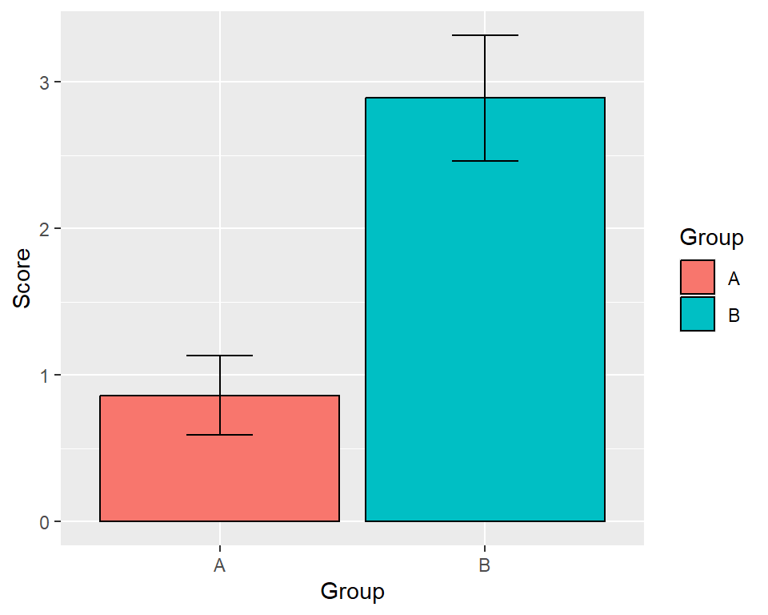

```r
# Subset values from tidy data
data_AB <- filter(data_tidy, Group == "A" | Group == "B")

# Use summarise() to compute everything I need for the plot
plot_data <- data_AB |>
  group_by(Group) |>
  summarise(
    n = length(Score),
    m = mean(Score),
    se = sd(Score) / sqrt(n),
    df = n - 1,
    alpha = 0.05,
    t_crit = abs(qt(alpha / 2, df = df)),
    moe = t_crit * se
  )

# Plot
ggplot(plot_data, aes(x = Group, y = m)) +
  geom_bar(stat = "identity", colour = "black", aes(fill = Group)) +
  geom_errorbar(
    aes(
      ymin = m - moe,
      ymax = m + moe
    ),
    width = 0.25
  ) +
  xlab("Group") +
  ylab("Score")
```

#### **2. E vs F: $H_0: \mu_E - \mu_F = 0$**

**Click for Solution**

```r
n1 <- length(data$E)
n2 <- length(data$F)

# Pooled Variance
sp_sq <- ((n1 - 1) * var(data$E) + (n2 - 1) * var(data$F)) / (n1 + n2 - 2)

# Pooled Standard Error
se <- sqrt(sp_sq / n1 + sp_sq / n2)

# Test Statistic
mu <- 0
diff <- mean(data$E) - mean(data$F)
t_stat <- (diff - mu) / se

# Degrees of Freedom
df <- (n1 - 1) + (n2 - 1)

# p-value
p <- pt(abs(t_stat), df = df, lower.tail = FALSE) * 2

# Confidence Interval
alpha <- 0.05
t_crit <- abs(qt(alpha / 2, df = df))

CI_bot <- diff - t_crit * se
CI_top <- diff + t_crit * se
CI <- paste("[", round(CI_bot, 3),
  ", ", round(CI_top, 3),
  "]",
  sep = ""
)

# Cohen's d
d <- diff / sqrt(sp_sq)

# Hedge's g
g <- d * (1 - (3 / (4 * (n1 + n2) - 9)))
```

```
## T = -5.621
## df = 398
## p = 3.573304e-08
## CI = [-1.222, -0.589]
## d = -0.562
## g = -0.561
```

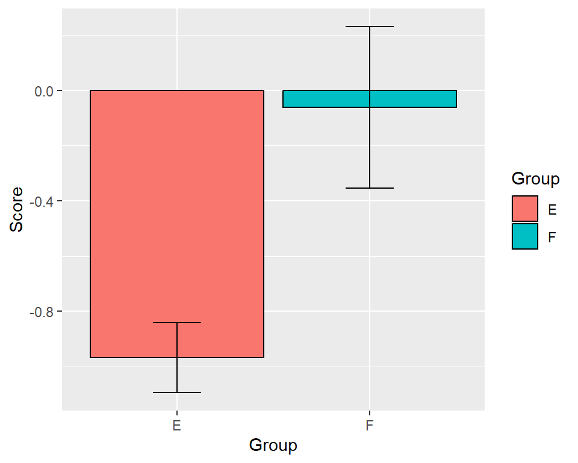

```r
# Subset values from tidy data
dataEF <- filter(data_tidy, Group == "E" | Group == "F")

# Use summarise() to compute everything I need for the plot
plot_data <- dataEF |>
  group_by(Group) |>
  summarise(
    n = length(Score),
    m = mean(Score),
    se = sd(Score) / sqrt(n),
    df = n - 1,
    alpha = 0.05,
    t_crit = abs(qt(alpha / 2, df = df)),
    moe = t_crit * se
  )

# Plot
ggplot(plot_data, aes(x = Group, y = m)) +
  geom_bar(stat = "identity", colour = "black", aes(fill = Group)) +
  geom_errorbar(
    aes(
      ymin = m - moe,
      ymax = m + moe
    ),
    width = 0.25
  ) +
  xlab("Group") +
  ylab("Score")
```

*Plots like this are why it’s usually helpful to subtract the bigger group from the smaller group. This is, technically, not wrong. It is just very awkward to look at.*

#### **3. D vs F: $H_0: \mu_D - \mu_F < 0$**

**Click for Solution**

```r
n1 <- length(data$D)
n2 <- length(data$F)

# Pooled Variance
sp_sq <- ((n1 - 1) * var(data$D) + (n2 - 1) * var(data$F)) / (n1 + n2 - 2)

# Pooled Standard Error
se <- sqrt(sp_sq / n1 + sp_sq / n2)

# Test Statistic
mu <- 0
diff <- mean(data$D) - mean(data$F)
t_stat <- (diff - mu) / se

# Degrees of Freedom
df <- (n1 - 1) + (n2 - 1)

# p-value
p <- pt(t_stat, df = df, lower.tail = FALSE)

# Confidence Interval
alpha <- 0.05
t_crit <- abs(qt(alpha, df = df))

CI_bot <- diff - t_crit * se
CI_top <- diff + Inf
CI <- paste("[",
        round(CI_bot, 3),
  ", ", round(CI_top, 3),
  "]",
  sep = ""
)

# Cohen's d
d <- diff / sqrt(sp_sq)

# Hedge's g
g <- d * (1 - (3 / (4 * (n1 + n2) - 9)))
```

```
## T = -5.68
## df = 398
## p = 1
## CI = [-1.202, Inf]
## d = -0.568
## g = -0.567
```

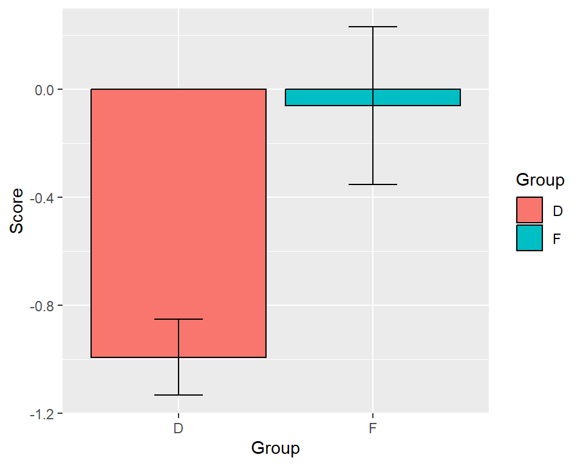

```r
# Subset values from tidy data
dataDF <- filter(data_tidy, Group == "D" | Group == "F")

# Use summarise() to compute everything I need for the plot
plot_data <- dataDF |>
  group_by(Group) |>
  summarise(
    n = length(Score),
    m = mean(Score),
    se = sd(Score) / sqrt(n),
    df = n - 1,
    alpha = 0.05,
    t_crit = abs(qt(alpha / 2, df = df)),
    moe = t_crit * se
  )


# Plot
ggplot(plot_data, aes(x = Group, y = m)) +
  geom_bar(stat = "identity", colour = "black", aes(fill = Group)) +
  geom_errorbar(
    aes(
      ymin = m - moe,
      ymax = m + moe
    ),
    width = 0.25
  ) +
  xlab("Group") +
  ylab("Score")
```

#### **4. G vs H: $H_0: \mu_G - \mu_H < -0.11$**

**Click for Solution**

```r
n1 <- length(data$G)
n2 <- length(data$H)

# Pooled Variance
sp_sq <- ((n1 - 1) * var(data$G) + (n2 - 1) * var(data$H)) / (n1 + n2 - 2)

# Pooled Standard Error
se <- sqrt(sp_sq / n1 + sp_sq / n2)

# Test Statistic
mu <- -0.11
diff <- mean(data$G) - mean(data$H)
t_stat <- (diff - mu) / se

# Degrees of Freedom
df <- (n1 - 1) + (n2 - 1)

# p-value
p <- pt(t_stat, df = df, lower.tail = FALSE)

# Confidence Interval
alpha <- 0.05
t_crit <- abs(qt(alpha, df = df))

CI_bot <- diff - t_crit * se
CI_top <- diff + Inf
CI <- paste(
  "[",  round(CI_bot, 3),
  ", ", round(CI_top, 3),
  "]",
  sep = ""
)

# Cohen's d
d <- diff / sqrt(sp_sq)

# Hedge's g
g <- d * (1 - (3 / (4 * (n1 + n2) - 9)))
```

```
## T = 11.741
## df = 398
## p = 7.780434e-28
## CI = [1.587, Inf]
## d = 1.109
## g = 1.107
```

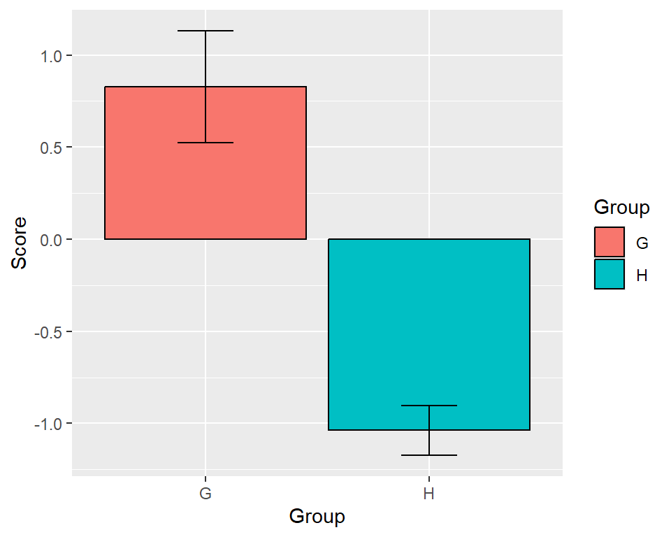

```r
# Subset values from tidy data
dataGH <- filter(data_tidy, Group == "G" | Group == "H")

# Use summarise() to compute everything I need for the plot
plot_data <- dataGH |>
  group_by(Group) |>
  summarise(
    n = length(Score),
    m = mean(Score),
    se = sd(Score) / sqrt(n),
    df = n - 1,
    alpha = 0.05,
    t_crit = abs(qt(alpha / 2, df = df)),
    moe = t_crit * se
  )

# Plot
ggplot(plot_data, aes(x = Group, y = m)) +
  geom_bar(stat = "identity", colour = "black", aes(fill = Group)) +
  geom_errorbar(
    aes(
      ymin = m - moe,
      ymax = m + moe
    ),
    width = 0.25
  ) +
  xlab("Group") +
  ylab("Score")
```

# Question 10.

### Repeat the previous question using a Welch’s T-test. Don’t bother plotting the means or calculating Cohen’s d and Hedge’s g.

#### **1. A vs B: $H_0: \mu_A - \mu_B = 0$**

**Click for Solution**

```r
n1 <- length(data$A)
n2 <- length(data$B)

var1 <- var(data$A)
var2 <- var(data$B)

# Standard Error of the Difference
se <- sqrt(var1 / n1 + var2 / n2)

# Test Statistic
mu <- 0
diff <- mean(data$A) - mean(data$B)
t_stat <- (diff - mu) / se

# Degrees of Freedom
q1 <- var1 / n1
q2 <- var2 / n2

df <- ((q1 + q2)^2) /
  (((q1^2) / (n1 - 1)) + ((q2^2) / (n2 - 1)))

# p-value
p <- pt(abs(t_stat), df = df, lower.tail = FALSE) * 2

# Confidence Interval
alpha <- 0.05
t_crit <- abs(qt(alpha / 2, df = df))

CI_bot <- diff - t_crit * se
CI_top <- diff + t_crit * se
CI <- paste(
  "[",
  round(CI_bot, 3), ", ",
  round(CI_top, 3),
  "]",
  sep = ""
)
```

```
## T = -7.913
## df = 337.4244
## p = 3.642909e-14
## CI = [-2.533, -1.524]
```

#### **2. E vs F: $H_0: \mu_E - \mu_F = 0$**

**Click for Solution**

```r
n1 <- length(data$E)
n2 <- length(data$F)

var1 <- var(data$E)
var2 <- var(data$F)

# Standard Error of the Difference
se <- sqrt(var1 / n1 + var2 / n2)

# Test Statistic
mu <- 0
diff <- mean(data$E) - mean(data$F)
t_stat <- (diff - mu) / se

# Degrees of Freedom
q1 <- var1 / n1
q2 <- var2 / n2

df <- ((q1 + q2)^2) /
  (((q1^2) / (n1 - 1)) + ((q2^2) / (n2 - 1)))

# p-value
p <- pt(abs(t_stat), df = df, lower.tail = FALSE) * 2

# Confidence Interval
alpha <- 0.05
t_crit <- abs(qt(alpha / 2, df = df))

CI_bot <- diff - t_crit * se
CI_top <- diff + t_crit * se
CI <- paste(
  "[",
  round(CI_bot, 3), ", ",
  round(CI_top, 3),
  "]",
  sep = ""
)
```

```
## T = -5.621
## df = 271.2831
## p = 4.705299e-08
## CI = [-1.223, -0.588]
```

#### **3. D vs F: $H_0: \mu_D - \mu_F < 0$**

**Click for Solution**

```r
n1 <- length(data$D)
n2 <- length(data$F)

var1 <- var(data$D)
var2 <- var(data$F)

# Standard Error of the Difference
se <- sqrt(var1 / n1 + var2 / n2)

# Test Statistic
mu <- 0
diff <- mean(data$D) - mean(data$F)
t_stat <- (diff - mu) / se

# Degrees of Freedom
q1 <- var1 / n1
q2 <- var2 / n2

df <- ((q1 + q2)^2) /
  (((q1^2) / (n1 - 1)) + ((q2^2) / (n2 - 1)))

# p-value
p <- pt(t_stat, df = df, lower.tail = FALSE)

# Confidence Interval
alpha <- 0.05
t_crit <- abs(qt(alpha, df = df))

CI_bot <- diff - t_crit * se
CI_top <- diff + Inf
CI <- paste(
  "[",
  round(CI_bot, 3), ", ",
  round(CI_top, 3),
  "]",
  sep = ""
)
```

```
## T = -5.68
## df = 286.2666
## p = 1
## CI = [-1.202, Inf]
```

#### **4. G vs H: $H_0: \mu_G - \mu_H < -0.11$**

**Click for Solution**

```r
n1 <- length(data$G)
n2 <- length(data$H)

var1 <- var(data$G)
var2 <- var(data$H)

# Standard Error of the Difference
se <- sqrt(var1 / n1 + var2 / n2)

# Test Statistic
mu <- -0.11
diff <- mean(data$G) - mean(data$H)
t_stat <- (diff - mu) / se

# Degrees of Freedom
q1 <- var1 / n1
q2 <- var2 / n2

df <- ((q1 + q2)^2) /
  (((q1^2) / (n1 - 1)) + ((q2^2) / (n2 - 1)))

# p-value
p <- pt(t_stat, df = df, lower.tail = FALSE)

# Confidence Interval
alpha <- 0.05
t_crit <- abs(qt(alpha / 2, df = df))

CI_bot <- diff - t_crit * se
CI_top <- diff + Inf
CI <- paste(
  "[",
  round(CI_bot, 3), ", ",
  round(CI_top, 3),
  "]",
  sep = ""
)
```

```
## T = 11.741
## df = 275.5515
## p = 2.214444e-26
## CI = [1.534, Inf]
```

# Question 11.

### Repeat the previous question using Trimmed T-tests with 20% trimming. For each, plot a bar graph of the means using two-sided 95% confidence intervals on the trimmed mean. You are not allowed to used `yuen()`.

- Note: if you use `yuen()` to check your answers you may need to factor your columns first. Also, `yuen()` only computes two-sided tests and does not allow you to specify $\mu$.

#### **1. A vs B: $H_0: \mu_A - \mu_B = 0$**

**Click for Solution**

```r
n1 <- length(data$A)
n2 <- length(data$B)

# Trim Prop.
G <- 0.20

# Means
m1 <- mean(data$A, tr = G)
m2 <- mean(data$B, tr = G)

# Winsorized Variances
var1 <- winvar(data$A, tr = G)
var2 <- winvar(data$B, tr = G)

# Observations left after trimming
h1 <- n1 - 2 * floor(G * n1)
h2 <- n2 - 2 * floor(G * n2)

# Squared Standard Error
d1 <- ((n1 - 1) * var1) / (h1 * (h1 - 1))
d2 <- ((n2 - 1) * var2) / (h2 * (h2 - 1))

# Degrees of Freedom
df <- ((d1 + d2)^2) /
  (((d1^2) / (h1 - 1)) + ((d2^2) / (h2 - 1)))

# Test Statistic
mu <- 0
diff <- m1 - m2
t_stat <- (diff - mu) / sqrt(d1 + d2)

# p-value
p <- pt(abs(t_stat), df = df, lower.tail = FALSE) * 2

# Confidence Interval
alpha <- 0.05
t_crit <- abs(qt(alpha / 2, df = df))

CI_bot <- diff - t_crit * sqrt(d1 + d2)
CI_top <- diff + t_crit * sqrt(d1 + d2)
CI <- paste("[", round(CI_bot, 3),
  ", ", round(CI_top, 3),
  "]",
  sep = ""
)
```

```
## T = -8.642
## df = 198.1408
## p = 1.845119e-15
## CI = [-2.657, -1.67]
```

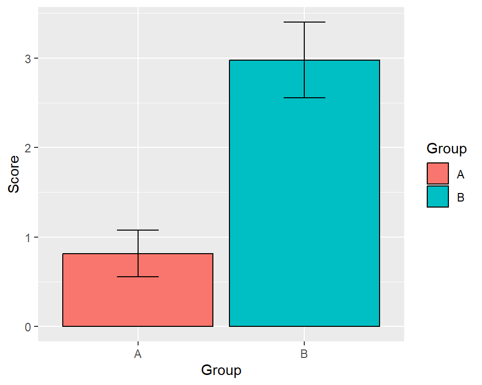

```r
plot_data <- data_AB |>
  group_by(Group) |>
  summarise(
    n = length(Score),
    G = 0.20,
    m = mean(Score, tr = G),
    s = sqrt(winvar(Score, tr = G)),
    se = s / ((1 - 2 * G) * sqrt(n)),
    h = n - 2 * floor(G * n),
    df = h - 1,
    alpha = 0.05,
    t_crit = abs(qt(alpha / 2, df = df)),
    moe = t_crit * se
  )


# Plot
ggplot(plot_data, aes(x = Group, y = m)) +
  geom_bar(stat = "identity", colour = "black", aes(fill = Group)) +
  geom_errorbar(
    aes(
      ymin = m - moe,
      ymax = m + moe
    ),
    width = 0.25
  ) +
  xlab("Group") +
  ylab("Score")
```

#### **2. E vs F: $H_0: \mu_E - \mu_F = 0$**

**Click for Solution**

```r
n1 <- length(data$E)
n2 <- length(data$F)

# Trim Prop.
G <- 0.20

# Means
m1 <- mean(data$E, tr = G)
m2 <- mean(data$F, tr = G)

# Winsorized Variances
var1 <- winvar(data$E, tr = G)
var2 <- winvar(data$F, tr = G)

# Observations left after trimming
h1 <- n1 - 2 * floor(G * n1)
h2 <- n2 - 2 * floor(G * n2)

# Squared Standard Error
d1 <- ((n1 - 1) * var1) / (h1 * (h1 - 1))
d2 <- ((n2 - 1) * var2) / (h2 * (h2 - 1))

# Degrees of Freedom
df <- ((d1 + d2)^2) /
  (((d1^2) / (h1 - 1)) + ((d2^2) / (h2 - 1)))

# Test Statistic
mu <- 0
diff <- m1 - m2
t_stat <- (diff - mu) / sqrt(d1 + d2)

# p-value
p <- pt(abs(t_stat), df = df, lower.tail = FALSE) * 2

# Confidence Interval
alpha <- 0.05
t_crit <- qt(alpha / 2, df = df, lower.tail = FALSE)

CI_bot <- diff - t_crit * sqrt(d1 + d2)
CI_top <- diff + t_crit * sqrt(d1 + d2)
CI <- paste(
  "[",
  round(CI_bot, 3), ", ",
  round(CI_top, 3),
  "]",
  sep = ""
)
```

```
## T = -4.708
## df = 165.9105
## p = 5.250576e-06
## CI = [-1.202, -0.492]
```

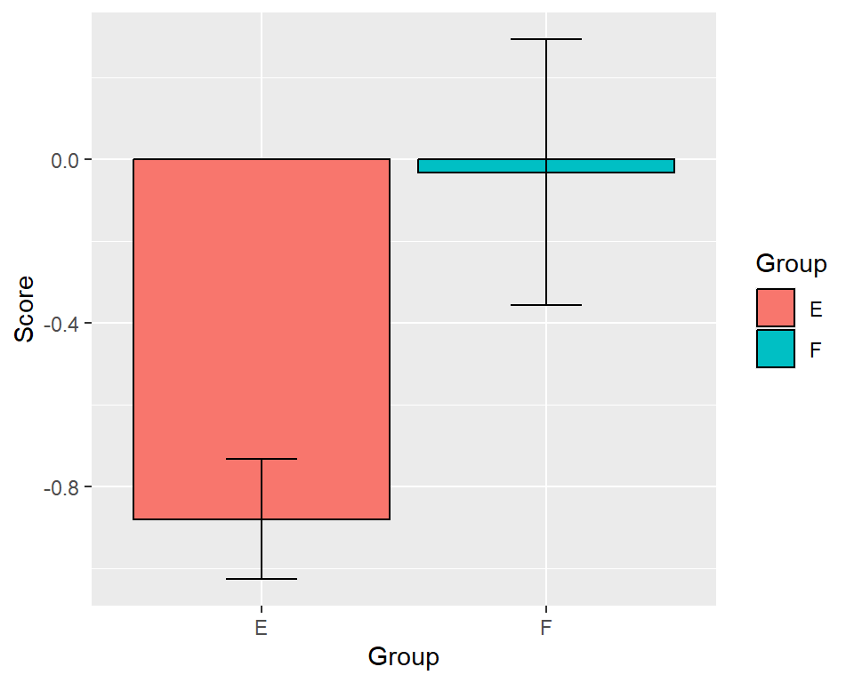

```r
plot_data <- dataEF |>
  group_by(Group) |>
  summarise(
    n = length(Score),
    G = 0.20,
    m = mean(Score, tr = G),
    s = sqrt(winvar(Score, tr = G)),
    se = s / ((1 - 2 * G) * sqrt(n)),
    h = n - 2 * floor(G * n),
    df = h - 1,
    alpha = 0.05,
    t_crit = abs(qt(alpha / 2, df = df)),
    moe = t_crit * se
  )


# Plot
ggplot(plot_data, aes(x = Group, y = m)) +
  geom_bar(stat = "identity", colour = "black", aes(fill = Group)) +
  geom_errorbar(
    aes(
      ymin = m - moe,
      ymax = m + moe
    ),
    width = 0.25
  ) +
  xlab("Group") +
  ylab("Score")
```

#### **3. D vs F: $H_0: \mu_D - \mu_F < 0$**

**Click for Solution**

```r
n1 <- length(data$D)
n2 <- length(data$F)

# Trim Prop.
G <- 0.20

# Means
m1 <- mean(data$D, tr = G)
m2 <- mean(data$F, tr = G)

# Winsorized Variances
var1 <- winvar(data$D, tr = G)
var2 <- winvar(data$F, tr = G)

# Observations left after trimming
h1 <- n1 - 2 * floor(G * n1)
h2 <- n2 - 2 * floor(G * n2)

# Squared Standard Error
d1 <- ((n1 - 1) * var1) / (h1 * (h1 - 1))
d2 <- ((n2 - 1) * var2) / (h2 * (h2 - 1))

# Degrees of Freedom
df <- ((d1 + d2)^2) /
  (((d1^2) / (h1 - 1)) + ((d2^2) / (h2 - 1)))

# Test Statistic
mu <- 0
diff <- m1 - m2
t_stat <- (diff - mu) / sqrt(d1 + d2)

# p-value
p <- pt(t_stat, df = df, lower.tail = FALSE)

# Confidence Interval
alpha <- 0.05
t_crit <- abs(qt(alpha, df = df))

CI_bot <- diff - t_crit * sqrt(d1 + d2)
CI_top <- diff + Inf
CI <- paste(
  "[",
  round(CI_bot, 3), ", ",
  round(CI_top, 3),
  "]",
  sep = ""
)
```

```
## T = -5.413
## df = 162.1299
## p = 0.9999999
## CI = [-1.262, Inf]
```

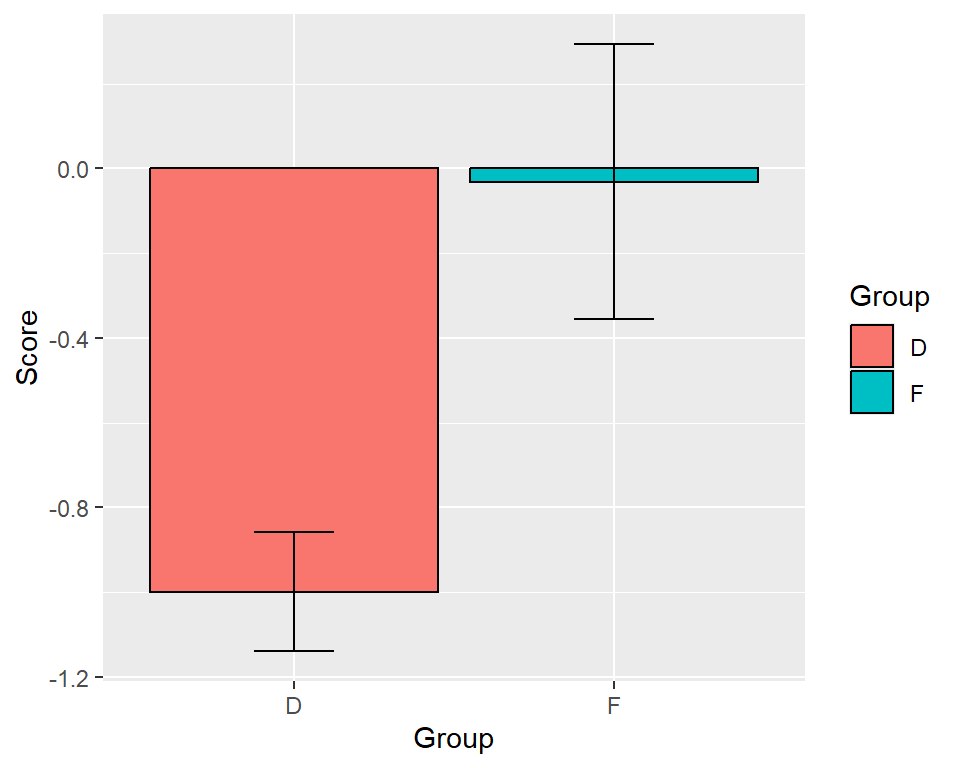

```r
plot_data <- dataDF |>
  group_by(Group) |>
  summarise(
    n = length(Score),
    G = 0.20,
    m = mean(Score, tr = G),
    s = sqrt(winvar(Score, tr = G)),
    se = s / ((1 - 2 * G) * sqrt(n)),
    h = n - 2 * floor(G * n),
    df = h - 1,
    alpha = 0.05,
    t_crit = abs(qt(alpha / 2, df = df)),
    moe = t_crit * se
  )

# Plot
ggplot(plot_data, aes(x = Group, y = m)) +
  geom_bar(stat = "identity", colour = "black", aes(fill = Group)) +
  geom_errorbar(
    aes(
      ymin = m - moe,
      ymax = m + moe
    ),
    width = 0.25
  ) +
  xlab("Group") +
  ylab("Score")
```

#### **4. G vs H: $H_0: \mu_G - \mu_H < -0.11$**

**Click for Solution**

```r
n1 <- length(data$G)
n2 <- length(data$H)

# Trim Prop.
G <- 0.20

# Means
m1 <- mean(data$G, tr = G)
m2 <- mean(data$H, tr = G)

# Winsorized Variances
var1 <- winvar(data$G, tr = G)
var2 <- winvar(data$H, tr = G)

# Observations left after trimming
h1 <- n1 - 2 * floor(G * n1)
h2 <- n2 - 2 * floor(G * n2)

# Squared Standard Error
d1 <- ((n1 - 1) * var1) / (h1 * (h1 - 1))
d2 <- ((n2 - 1) * var2) / (h2 * (h2 - 1))

# Degrees of Freedom
df <- ((d1 + d2)^2) /
  (((d1^2) / (h1 - 1)) + ((d2^2) / (h2 - 1)))

# Test Statistic
mu <- -0.11
diff <- m1 - m2
t_stat <- (diff - mu) / sqrt(d1 + d2)

# p-value
p <- pt(t_stat, df = df, lower.tail = FALSE)

# Confidence Interval
alpha <- 0.05
t_crit <- abs(qt(alpha, df = df))

CI_bot <- diff - t_crit * sqrt(d1 + d2)
CI_top <- diff + Inf
CI <- paste("[", round(CI_bot, 3),
  ", ", round(CI_top, 3),
  "]",
  sep = ""
)
```

```
## T = 11.578
## df = 175.7637
## p = 1.056332e-23
## CI = [1.723, Inf]
```

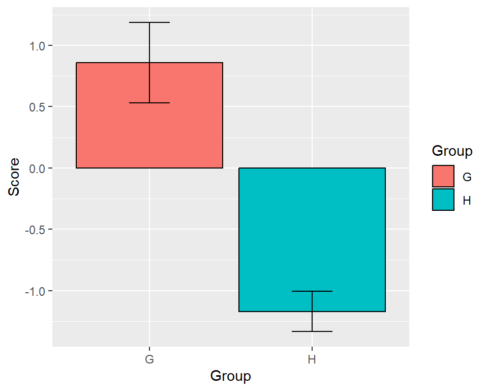

```r
plot_data <- dataGH |>
  group_by(Group) |>
  summarise(
    n = length(Score),
    G = 0.20,
    m = mean(Score, tr = G),
    s = sqrt(winvar(Score, tr = G)),
    se = s / ((1 - 2 * G) * sqrt(n)),
    h = n - 2 * floor(G * n),
    df = h - 1,
    alpha = 0.05,
    t_crit = abs(qt(alpha / 2, df = df)),
    moe = t_crit * se
  )

# Plot
ggplot(plot_data, aes(x = Group, y = m)) +
  geom_bar(stat = "identity", colour = "black", aes(fill = Group)) +
  geom_errorbar(
    aes(
      ymin = m - moe,
      ymax = m + moe
    ),
    width = 0.25
  ) +
  xlab("Group") +
  ylab("Score")
```

# Question 12.

### Your friend Bertrand scores a 66 in their philosophy class. What percentile does this put them at? Assume the class marks are normally distributed with a mean of 79.6 and a standard deviation of 12.95.

**Click for Solution**

**Two ways to solve this:**

**Option 1:**

```r
pnorm(66, mean = 79.6, sd = 12.95) * 100
```

```
## [1] 14.68147
```

**Option 2:**

```r
z <- (66 - 79.6)/12.95
pnorm(z, mean = 0, sd = 1) * 100
```

```
## [1] 14.68147
```

# Question 13.

### From the previous question, how many standard deviations above or below the mean are they?

**Click for Solution**

```r
z <- (66 - 79.6) / 12.95
z
```

```
## [1] -1.050193
```

They are 1.05 standard deviations below the mean.

# Question 14.

### Your other friend (Jimbo) is 0.98 standard deviations below the mean in their philosophy class. What percentile does this put them at? Assume the class marks are normally distributed with a mean of 79.6 and a standard deviation of 12.95.

**Click for Solution**

```r
pnorm(-0.98, mean = 0, sd = 1) * 100
```

```
## [1] 16.35431
```

# Question 15.

### From the previous question, what percentage of students scored higher than your friend Jimbo?

**Click for Solution**

**Two ways to solve this:**

**Option 1:**

```r
(1 - pnorm(-0.98, mean = 0, sd = 1)) * 100
```

```
## [1] 83.64569
```

**Option 2:**

```r
pnorm(-0.98, mean = 0, sd = 1, lower.tail = FALSE) * 100
```

```
## [1] 83.64569
```